# Imports and functions

```python
import pandas as pd
import matplotlib.pyplot as plt
import plotly.express as px
import plotly.io as pio
pio.renderers.default = "iframe"

def no_show_average(feature, data):
    """
    It returns the average of the no-show occurrence and the number of events per feature
    """
    avgs = {var:100*data[data[feature] == var].no_show.mean() for var in set(data[feature])}
    count = {var:100*data[data[feature] == var].no_show.count() for var in set(data[feature])}
    df = pd.DataFrame(index=avgs.keys())
    df.index.name = feature
    df['No show average [%]'.format(feature)] = avgs.values()
    df['Count'] = count.values()
    return df.round(2)

def single_feature_impact(feature, data):
    fig = px.histogram(data,
                       y = 'no_show',
                       histnorm = 'percent',
                       orientation='h',
                       width=800,
                       height=300,
                       color=feature,
                       barmode='group',
                       title=f"Show/No show percentages by: {feature}".title(),
                       labels={'no_show': 'No show rate'}
                      )
    fig.show()
```

# Introduction

Aim of this notebook is to summarize and document the analysis done for the dataset contained in the csv file `noshowappointments-kagglev2-may-2016.csv`. This notebook contains all the most relevant findings while more details can be found in [project github repository](https://github.com/gpagliuca/soccer.git).

The following information was available together with the data:

> This dataset collects information from 100k medical appointments in Brazil and is focused on the question of whether or not patients show up for their appointment. A number of characteristics about the patient are included in each row.
> - **ScheduledDay** tells us on what day the patient set up their appointment.
> - **Neighborhood** indicates the location of the hospital.
> - **Scholarship** indicates whether or not the patient is enrolled in Brasilian welfare program Bolsa Família.
> - Be careful about the encoding of the last column: it says ‘No’ if the patient showed up to their appointment, and ‘Yes’ if they did not show up.

## Typical questions

1. What factors are important for us to know in order to predict if a patient will show up for their scheduled appointment?
2. How many appointments per patient on average
3. What are the main limitations in the dataset?

# Data loading and cleaning

```python
df = pd.read_csv('../00_data/noshowappointments-kagglev2-may-2016.csv')
df.head(2)
```

|  | PatientId | AppointmentID | Gender | ScheduledDay | AppointmentDay | Age | Neighbourhood | Scholarship | Hipertension | Diabetes | Alcoholism | Handcap | SMS_received | No-show |
| --- | --- | --- | --- | --- | --- | --- | --- | --- | --- | --- | --- | --- | --- | --- |
| 0 | 2.987250e+13 | 5642903 | F | 2016-04-29T18:38:08Z | 2016-04-29T00:00:00Z | 62 | JARDIM DA PENHA | 0 | 1 | 0 | 0 | 0 | 0 | No |
| 1 | 5.589978e+14 | 5642503 | M | 2016-04-29T16:08:27Z | 2016-04-29T00:00:00Z | 56 | JARDIM DA PENHA | 0 | 0 | 0 | 0 | 0 | 0 | No |

## First considerations

Using the `shape`, `info`, `describe` and `duplicated` properties it is possible to determine that:

- The original dataset contains 110527 rows and 14 columns
- Depending on the feature the data type is either string, float or integer
- There are no duplicates
- No NA values either
- There are 110527 **appointments** but only 62299 **patients**: some patients had multiple appointments
- The minimum **age** is -1, the maximum one is 115
- **Gender**, **Scholarship**, **Hipertension**, **Diabetes**, **Alcoholism** and **No-Show** are all binary features
- **Handcap** ranges from 0 to 4

## Dataset modifications

To better evaluate the dataset some changes have been applied:

```python
## Changes to the original dataset

# Drop AppointmentDay since it is redundant
df_mod = df.drop('AppointmentDay', axis=1)
# Switch to datetime
df_mod['ScheduledDay'] = pd.to_datetime(df_mod['ScheduledDay'])
# Replace No-show with a boolean
df_mod['no_show'] = df_mod['No-show'] == 'Yes'
df_mod.drop('No-show', axis=1, inplace=True)
# Create a health index
df_mod['health_index'] = df_mod['Hipertension'] + df_mod['Diabetes'] + df_mod['Alcoholism']
# Replace negative ages with zero
s = df_mod['Age'].copy()
s[s < 0] = 0
df_mod['Age'] = s
# Group by age
df_mod['age_grouped']  = pd.cut(df_mod['Age'], [-1, 20, 70, df_mod['Age'].max()+1], labels=['Young', 'Adults', 'Elderly'])
# Add weekday
df_mod['weekday'] = [d.weekday() for d in df_mod['ScheduledDay']]
# Add morning
df_mod['morning'] = [True if d.hour<=12 else False for d in df_mod['ScheduledDay'] ]

# Replacing zeros and ones for plotting esthetics
for feature in df.columns[6:13]:
    df_mod[feature].replace([0, 1], [False, True], inplace=True)

df_mod.head(2)
```

|  | PatientId | AppointmentID | Gender | ScheduledDay | Age | Neighbourhood | Scholarship | Hipertension | Diabetes | Alcoholism | Handcap | SMS_received | no_show | health_index | age_grouped | weekday | morning |
| --- | --- | --- | --- | --- | --- | --- | --- | --- | --- | --- | --- | --- | --- | --- | --- | --- | --- |
| 0 | 2.987250e+13 | 5642903 | F | 2016-04-29 18:38:08+00:00 | 62 | JARDIM DA PENHA | False | True | False | False | False | False | False | 1 | Adults | 4 | False |
| 1 | 5.589978e+14 | 5642503 | M | 2016-04-29 16:08:27+00:00 | 56 | JARDIM DA PENHA | False | False | False | False | False | False | False | 0 | Adults | 4 | False |

# Impact of a single feature on the no-show rate

On average on the whole dataset thew no show rate is slightly bigger than 20% like shown in the plot below:

```python
fig = px.histogram(df_mod,
                   y = 'no_show',
                   histnorm = 'percent',
                   orientation='h',
                   width=800,
                   height=250,
                   title='Overall no-show rate',
                   labels={'no_show': 'No show rate'}
                  )

fig.show()
```

[interactive chart not shown]

The impact of each feature on the no-show occurrence has been evaluated. The most relevant features are reported below:

## Scholarship

Patients who were part of the Bolsa Família program seems to have a slightly higher no-show occurrence rate.

```python
no_show_average('Scholarship', df_mod)
```

| Scholarship | No show average [%] | Count |
| --- | --- | --- |
| False | 19.81 | 9966600 |
| True | 23.74 | 1086100 |

```python
single_feature_impact('Scholarship', df_mod)
```

[interactive chart not shown]

## SMS received

Apparently receiving a reminder via SMS increases the chances of a no-show. This counterintuitive conclusion should be studied better.

```python
no_show_average('SMS_received', df_mod)
```

| SMS_received | No show average [%] | Count |
| --- | --- | --- |
| False | 16.70 | 7504500 |
| True | 27.57 | 3548200 |

```python
single_feature_impact('SMS_received', df_mod)
```

[interactive chart not shown]

## Weekday

The weekday of the appointment makes little impact on the no-show rate. An exception is represented by Saturdays: in these days the no-show rate drops to only 4.17%. It is useful to underline, though, that the number of appointments organized on Saturdays is 3 orders of magnitude less than the other days of the week.

```python
weekday_df = no_show_average('weekday', df_mod)
weekday_df.index = ['Mon', 'Tue', 'Wed', 'Thu', 'Fri', 'Sat']
weekday_df
```

|  | No show average [%] | Count |
| --- | --- | --- |
| Mon | 19.76 | 2308500 |
| Tue | 20.22 | 2616800 |
| Wed | 20.11 | 2426200 |
| Thu | 20.47 | 1807300 |
| Fri | 20.55 | 1891500 |
| Sat | 4.17 | 2400 |

```python
single_feature_impact('weekday', df_mod)
```

[interactive chart not shown]

## Age (grouped)

Young patients have a higher no-show rate.

```python
no_show_average('age_grouped', df_mod)
```

| age_grouped | No show average [%] | Count |
| --- | --- | --- |
| Young | 22.28 | 3184900 |
| Elderly | 15.84 | 857300 |
| Adults | 19.78 | 7010500 |

```python
single_feature_impact('age_grouped', df_mod)
```

[interactive chart not shown]

## Neighbourhood

The two tables below report the top and bottom 5 neighborhoods in terms of no-show rate. If we exclude the first and the last ones (characterized by a very limited number of appointments) the no show rate is comprised between 8.57 and 28.92 %.  
The full detail is reported in the plot below.

```python
neighbourhood_no_show_occ = no_show_average("Neighbourhood", df_mod).sort_values('No show average [%]', ascending=False)
neighbourhood_no_show_occ.head()
```

| Neighbourhood | No show average [%] | Count |
| --- | --- | --- |
| ILHAS OCEÂNICAS DE TRINDADE | 100.00 | 200 |
| SANTOS DUMONT | 28.92 | 127600 |
| SANTA CECÍLIA | 27.46 | 44800 |
| SANTA CLARA | 26.48 | 50600 |
| ITARARÉ | 26.27 | 351400 |

```python
neighbourhood_no_show_occ.tail()
```

| Neighbourhood | No show average [%] | Count |
| --- | --- | --- |
| SOLON BORGES | 14.71 | 46900 |
| MÁRIO CYPRESTE | 14.56 | 37100 |
| AEROPORTO | 12.50 | 800 |
| ILHA DO BOI | 8.57 | 3500 |
| PARQUE INDUSTRIAL | 0.00 | 100 |

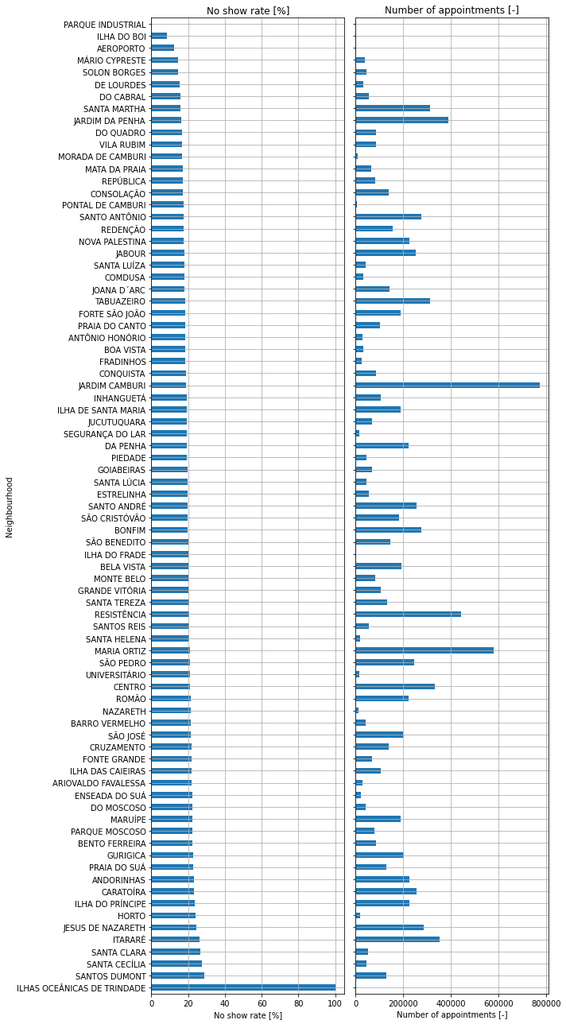

```python
fig, (ax0, ax1) = plt.subplots(ncols=2, figsize=(10, 18), sharey=True)
ax0.set_xlabel('No show rate [%]')
ax1.set_xlabel('Number of appointments [-]')
neighbourhood_no_show_occ['No show average [%]'].plot(kind='barh', ax=ax0, grid=True, title='No show rate [%]')
neighbourhood_no_show_occ['Count'].plot(kind='barh', ax=ax1, title='Number of appointments [-]', grid=True)
plt.tight_layout();
```

## No show rate of the most frequent patients

```python
most_freq_patients_ids = df_mod['PatientId'].value_counts().iloc[:100].index
most_frequent_patients = df_mod[df['PatientId'].isin(most_freq_patients_ids)]
most_frequent_patients.head(2)
```

|  | PatientId | AppointmentID | Gender | ScheduledDay | Age | Neighbourhood | Scholarship | Hipertension | Diabetes | Alcoholism | Handcap | SMS_received | no_show | health_index | age_grouped | weekday | morning |
| --- | --- | --- | --- | --- | --- | --- | --- | --- | --- | --- | --- | --- | --- | --- | --- | --- | --- |
| 218 | 8.485848e+14 | 5559082 | F | 2016-04-08 07:21:44+00:00 | 59 | ANDORINHAS | False | True | False | False | False | True | False | 1 | Adults | 4 | True |
| 611 | 6.932219e+13 | 5634230 | M | 2016-04-28 10:36:19+00:00 | 33 | ESTRELINHA | False | False | False | True | False | False | False | 1 | Adults | 3 | True |

```python
most_frequent_patients['no_show'].mean()
```

```
0.12538226299694188
```

The 100 patients with more appointments have a no-show rate of 12.54%, significantly lower respect the whole patients community (about 20%).

## Conclusions

# Features crosscheck

A visual representation of the combined impact of the `SMS_received`, `weekday` and `age_grouped` features is reported below. The first plot shows the no-show rate while the second one the no-show count.

```python
fig = px.histogram(df_mod,
                   y = 'no_show',
                   histnorm = 'percent',
                   orientation='h',
                   width=1200,
                   height=600,
                   color='SMS_received',
                   facet_col='weekday',
                   facet_row='age_grouped',
                   barmode='group',
                   text_auto='.1f',
                   category_orders=dict(weekday=[0, 1, 2, 3, 4, 5], age_grouped=['Young', 'Adults', 'Elderly']),
                   labels={'no_show': 'No Show', 'age_grouped': 'Age'},
                   title='Combined impact (expressed as no show rate) of SMS received, eekday and age features'
                  )

fig.show()
```

[interactive chart not shown]

```python
fig = px.histogram(df_mod,
                   y = 'no_show',
                   orientation='h',
                   width=1200,
                   height=600,
                   color='SMS_received',
                   facet_col='weekday',
                   facet_row='age_grouped',
                   barmode='group',
                   text_auto=True,
                   category_orders=dict(weekday=[0, 1, 2, 3, 4, 5], age_grouped=['Young', 'Adults', 'Elderly']),
                   labels={'no_show': 'No Show', 'age_grouped': 'Age'},
                   title='Combined impact (expressed in number of occurrances) of SMS received, eekday and age features'
                  )

fig.show()
```

[interactive chart not shown]

# Overall conclusions

In order to reduce the no show rate it is possible to suggest:

- Understand why young/adult patients are more likely to miss an appointment. One potential explanation might be the necessity to go to work or take care of other family members: offering more appointments outside typical working hours may help.
- Similarly to the previous conclusion offering more appointments in Saturdays should be considered
- The SMS reminder campaign seems to be ineffective, it should be further investigated why
- On average gender, pre-existing heath issues and offering an appointment in the mornings or afternoons do not significantly affect the no-show rate

# Dataset limitations and possible follow-up work

The dataset provided, although well structured, organized and without missing/duplicated data, does not give us:

- specific information about the type of medical appointment: are patients skipping “less relevant” appointments related to minor (or perceived as minor) health issues?
- any potential indication behind a no-show, the intake questionnaire may be updated including a question about previous no-show events
- information about the possibility to reach the hospital with a private car, this can help in understanding if public transportation is an issue or not

With more time and resources it could be interesting to perform the following additional activities:

- Cross-correlate the neighborhood with the local income and distance respect the nearest hospitals